# Effects of Borrower's Background on Interest Rate and Loan Outcomes

## by Qilin Zhang

## Investigation Overview

In this investigation, I wanted to figure out what factors affect a loan’s outcome status, and what affects the borrower interest rate in the dataset. I focued on income range, credit score, prosper rating, loan amount and loan term.

## Dataset Overview

This dataset includes approximately 114,000 loan records with 21 variables regarding loans' and borrowers' characteristics. 1929 pieces were removed from the analysis due to inconsistencies or missing information and 112,008 records left.

## Loan Outcome Status

Nearly 50% of the loans in the dataset are still in process. 35.5% are completed loans and 14.8% are defaulted ones.

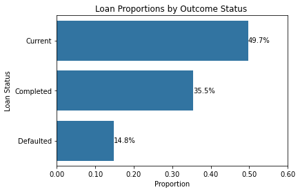

## Distributions of Borrower Interest Rate and Loan Amount

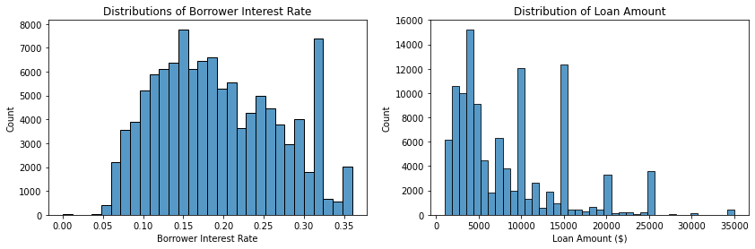

## Loan Categories

51.4% of the loans were for Debt consolidation. Other top loan purposes are home improvement and business.

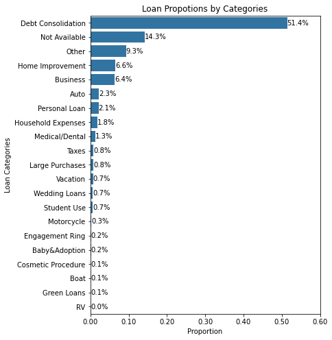

## Loan’s Defaulted Rate vs. Credit Score and Prosper Rating

Defaulted Rate is defined as the ratio between defaults and total number of loans that are not in process. Genrally, the higher the credit score is, the lower the defaulted rate. Similar pattern is also find in the relationship between defaulted rate and Prosper rating.

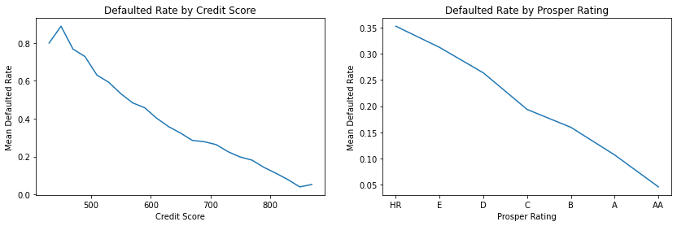

## Borrower Rate and Loan Amount by Prosper Rating and Loan Term

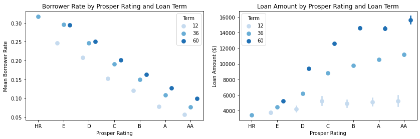